# Anreg Praktikum 2 (mandiri)

Fikar

2026-02-03

```r
library(readxl)
data <- read_excel("C:/Users/Hype AMD/IPB/Matakuliaih/Semester 4/Analisis Regresi/Pertemuan 2/NSC-2025.xlsx")
head(data) #menampilkan sebagian data awal
```

```
## # A tibble: 6 × 11
##   `Kabupaten/Kota`     `Indeks Pembangunan Manusia` `Rata-Rata Lama Sekolah`
##   <chr>                                       <dbl>                    <dbl>
## 1 Kepulauan Seribu                             76.7                     9.26
## 2 Kota Jakarta Selatan                         87.6                    12.0
## 3 Kota Jakarta Timur                           84.8                    12.0
## 4 Kota Jakarta Pusat                           83.8                    11.6
## 5 Kota Jakarta Barat                           84.4                    11.2
## 6 Kota Jakarta Utara                           82.1                    10.8
## # ℹ 8 more variables: `PDRB ADHK (MILYAR RUPIAH)` <dbl>,
## #   `Persentase Penduduk Miskin` <dbl>,
## #   `Persentase Akses Sanitasi Layak` <dbl>,
## #   `Kontribusi Sektor Industri Pengolahan teradap PDRB/PDB  (%)` <dbl>,
## #   `Pertumbuhan Ekonomi Sektor Industri Pengolahan` <dbl>,
## #   `Indeks Pembangunan Gender` <dbl>,
## #   `Tingkat Partisipasi Angkatan Kerja (TPAK)` <dbl>, …
```

#Menyesuaikan Peubah Untuk mempermudah pemanggilan peubah pada saat eksplorasi dan analisis, jika pada file masih mengggunakan nama peubah yang panjang, maka bisa diganti dengan menggunakan fungsi colnames(). Kolom wilayah juga dapat dihapus dengan menggunakan syntax namadata[,-1] dengan -1 menunjukkan bahwa kolom pertama ingin dihapus.

```r
colnames(data) <- c("Kabupaten/Kota", "Y", paste0("X", 1:9))
head(data)
```

```
## # A tibble: 6 × 11
##   `Kabupaten/Kota`      Y    X1     X2    X3    X4    X5    X6    X7    X8    X9
##   <chr>             <dbl> <dbl>  <dbl> <dbl> <dbl> <dbl> <dbl> <dbl> <dbl> <dbl>
## 1 Kepulauan Seribu   76.7  9.26 3.27e3 13.0   89.1  4.06  0.37  93.6  72.6  7.93
## 2 Kota Jakarta Sel…  87.6 12.0  5.00e5  3.03  92.6  1.38  3.74  97.3  64.8  5.22
## 3 Kota Jakarta Tim…  84.8 12.0  3.62e5  4.09  97.2 26.7   2.13  95.9  64.5  6.95
## 4 Kota Jakarta Pus…  83.8 11.6  5.33e5  4.63  90.3  0.84  0.01  96.2  65.1  6.24
## 5 Kota Jakarta Bar…  84.4 11.2  3.83e5  3.94  94.9  5.3   2.16  95.7  64.1  6.18
## 6 Kota Jakarta Uta…  82.1 10.8  3.80e5  6.44  91.4 30.3   0.52  94.4  67.8  6.18
```

#Eksplorasi data

```r
n <- nrow(data)
```

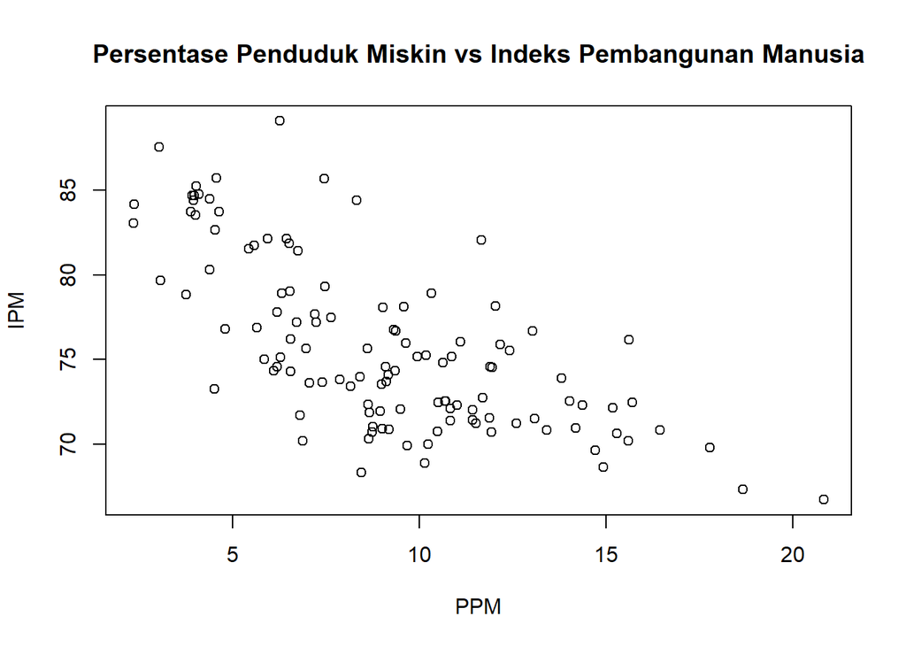

```r
plot(data$X3, data$Y, xlab="PPM", ylab="IPM", main="Persentase Penduduk Miskin vs Indeks Pembangunan Manusia")
```

```r
summary(data$Y)
```

```
##    Min. 1st Qu.  Median    Mean 3rd Qu.    Max.
##   66.72   71.91   74.57   75.75   78.86   89.10
```

```r
summary(data$X3)
```

```
##    Min. 1st Qu.  Median    Mean 3rd Qu.    Max.
##   2.340   6.380   8.980   9.074  11.425  20.830
```

[figure not shown]

```r
hist(data$Y, main="Histogram PPM", xlab="Indeks Pembangunan Manusia", col="lightblue", border="black")
```

[figure not shown]

```r
boxplot(data$Y, main="Boxplot PPM", ylab="Indeks Pembangunan Manusia", col="lightgreen")
```

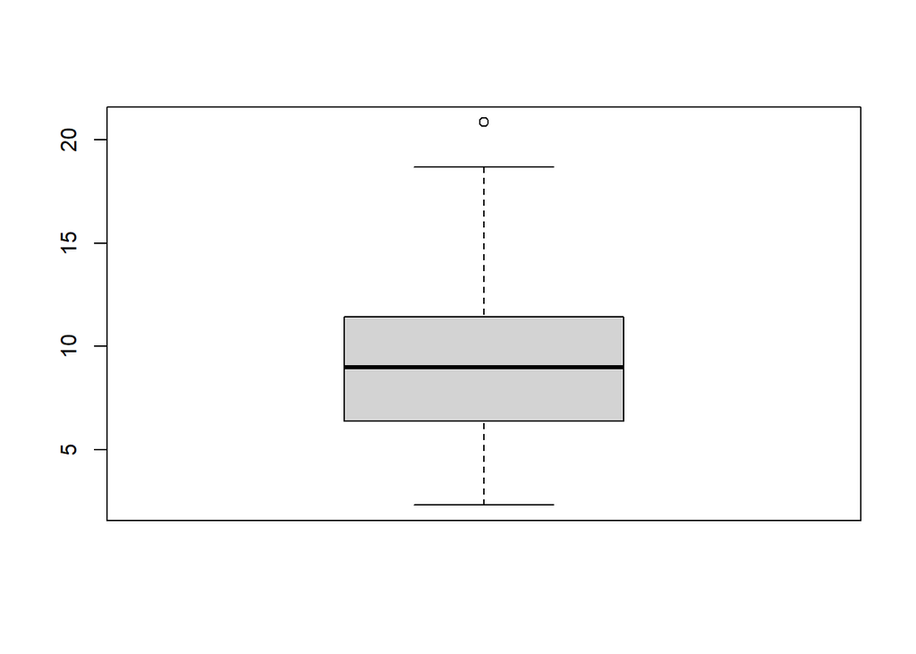

```r
boxplot(data$X3)
```

#Pembentukan Model Manual

```r
x <- data$X3
y <- data$Y
```

```r
b1 <- (sum(x*y)-sum(x)*sum(y)/n)/(sum(x^2)-(sum(x)^2/n))
b0 <- mean(y)-b1*mean(x)

cat("Koefisien b0:", b0, "\n")
```

```
## Koefisien b0: 84.2552
```

```r
cat("Koefisien b1:", b1, "\n")
```

```
## Koefisien b1: -0.9377205
```

#Standar Error Parameter Regresi Standar error menunjukan seberapa besar ketidakpastian dalam estimasi koefisien

```r
galat <- y-(b0+b1*x)
ragam_galat <- sum(galat^2)/(n-2)

se_b0 <- sqrt(ragam_galat*(1/n+mean(x)^2/sum((x-mean(x))^2)))
se_b1 <- sqrt(ragam_galat/sum((x-mean(x))^2))

cat("Standar error b0:", se_b0, "\n")
```

```
## Standar error b0: 0.8787893
```

```r
cat("Standar error b1:", se_b1, "\n")
```

```
## Standar error b1: 0.08966655
```

#Signifikansi Parameter (nilai-t) Nilai ini menunjukkan tingkat signifikansi secara parsial dari setiap koefisien peubah berdasarkan nilai t dan probabilitas nilai p

```r
t_b0 <- b0/se_b0
t_b1 <- b1/se_b1
p_b0 <- 2*pt(-abs(t_b0 ),df<-n-2)
p_b1 <- 2*pt(-abs(t_b1 ),df<-n-2)

cat("Nilai t pada b0 adalah", t_b0, "dengan nilai p sebesar", p_b0, "\n")
```

```
## Nilai t pada b0 adalah 95.87645 dengan nilai p sebesar 4.751831e-113
```

```r
cat("Nilai t pada b1 adalah", t_b1, "dengan nilai p sebesar", p_b1, "\n")
```

```
## Nilai t pada b1 adalah -10.45786 dengan nilai p sebesar 1.792162e-18
```

#Koefisien Determinasi dan Penyesuaiannya Pada analisis regresi linier sederhana, koefisien determinasi yang digunakan adalah multiple R Squared, sedangkan regresi linier berganda menggunakan adjusted R Squared yang disesuaikan dengan banyaknya peubah

```r
r <- (sum(x*y)-sum(x)*sum(y)/n)/
sqrt((sum(x^2)-(sum(x)^2/n))*(sum(y^2)-(sum(y)^2/n)))
Koef_det <- r^2
Koef_det
```

```
## [1] 0.48314
```

```r
Adj_R2 <- 1-((1-Koef_det)*(n-1)/(n-1-1))
Adj_R2
```

```
## [1] 0.4787224
```

#Signifikansi Simultan (F) Nilai ini menunjukkan signifikansi dan kebaikan model secara simultan (bersamaan seluruh peubah) yang menjelaskan model secara keseluruhan memiliki hubungan berarti antara X dan Y.

```r
galat<-y-(b0+b1*x)

JKG <- sum((y - (b0+b1*x))^2)
JKReg <- sum(((b0+b1*x)- mean(y))^2)
JKT <- sum((y - mean(y))^2)
JKT <- JKReg+JKG

dbReg <- 1
dbg <- n-2
dbt <- n-1

(Fhit <- (JKReg/dbReg)/(JKG/dbg))
```

```
## [1] 109.3669
```

```r
(p_F <- pf(Fhit, dbReg, dbg, lower.tail=FALSE))
```

```
## [1] 1.792162e-18
```

Nilai p F sebesar 0.000 yang lebih kecil dari alpha 0.05, maka dapat disimpulkan bahwa peubah X3 secara simultan berpengaruh signifikan terhadap peubah Y.

#Menggunakan Fungsi lm() Dalam penggunaan fungsi lm(), kita akan memperoleh secara langsung nilai-nilai pada pemodelan regresi dari data yang kita miliki. Hanya dengan mengeluarkan summary dan anova dari model yang terbentuk maka dapat diperoleh nilai parameter, signifikansinya, standar eror, koefisien determinasi hingga ukuran keragamannya.

```r
model <- lm(Y~X3, data = data)
summary(model)
```

```
##
## Call:
## lm(formula = Y ~ X3, data = data)
##
## Residuals:
##     Min      1Q  Median      3Q     Max
## -8.0108 -2.3263  0.0117  2.4857 10.7149
##
## Coefficients:
##             Estimate Std. Error t value Pr(>|t|)
## (Intercept) 84.25520    0.87879   95.88   <2e-16 ***
## X3          -0.93772    0.08967  -10.46   <2e-16 ***
## ---
## Signif. codes:  0 '***' 0.001 '**' 0.01 '*' 0.05 '.' 0.1 ' ' 1
##
## Residual standard error: 3.622 on 117 degrees of freedom
## Multiple R-squared:  0.4831, Adjusted R-squared:  0.4787
## F-statistic: 109.4 on 1 and 117 DF,  p-value: < 2.2e-16
```

```r
anova(model)
```

```
## Analysis of Variance Table
##
## Response: Y
##            Df Sum Sq Mean Sq F value    Pr(>F)
## X3          1 1434.7 1434.74  109.37 < 2.2e-16 ***
## Residuals 117 1534.9   13.12
## ---
## Signif. codes:  0 '***' 0.001 '**' 0.01 '*' 0.05 '.' 0.1 ' ' 1
```

dengan Y adalah index Pembangunan Manusia dan X3 adalah persentase penduduk miskin.